# STAT 1291: Principles of Data Science

HW 9 Solution

## Introduction

In this lab, you will use the `broom` package, by David Robinson, to turn results of many statistical analyses into tidy data.

## Australian twin sample biometric data

In this lab, we explore `twinData`, Australian twin data with 3808 observations on the 12 variables including body mass index (BMI) assessed in both MZ (identical) and DZ (fraternal) twins.

```r
library(tidyr)
library(dplyr)

#install.packages("OpenMx")
library(OpenMx)
data(twinData)
twinData <- as_tibble(twinData)
```

Type `help(twinData)` to understand the data set. The data table `twinData` appears to be tidy (*for some purposes*). Check that each column is a variable, and each row is an observation. Note that the unit of observation is not a person, but a family.

Suppose that we want to answer some questions:

1. Are the twins similar in height, weight and bmi?
2. Are the first-born taller than the second-born?

There are many other interesting questions you may pose, but let us focus on these two simple questions.

To answer the first question, we need to carefully reformuate the question. What does it mean that the twins’ heights are similar? Does it mean that if you know the older twin’s height, you can well predict the younger twin’s height?

## Homework

1. In terms of the relation between two variables, `ht1` and `ht2`, what does high similarity of heights imply?

“high similarity” implies:

- First, there is a strong, positive correlation between ‘ht1’ and ‘ht2’.
- The heights of twins are not significantly different.
2. Using ggplot2, create scatter plots to visually investigate the relation between `ht1` and `ht2`. The scatter plot gives some impression on the answer of the question, “yes”. Why?

From the scatterplot, we observe a moderately strong linear positive relationship between ‘ht1’ and ‘ht2’. In addition, there are a lot of points clustered around the diagonal line.

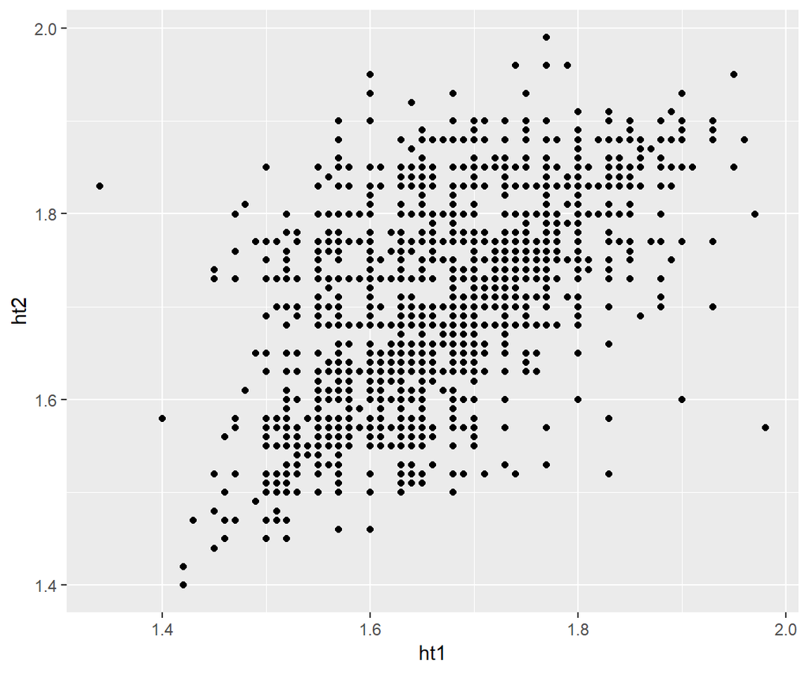

```r
library(ggplot2)
twinData %>% ggplot(mapping = aes(ht1, ht2)) +
  geom_point()
```

3. But, will the answer be the same if we use more information? Consider two more variables `cohort`, `zygosity`. Add more layers or use facet to include the information contained in these two variables.

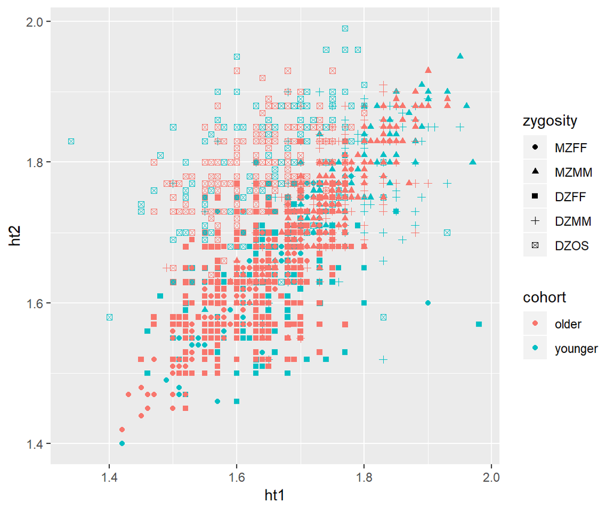

```r
library(ggplot2)
twinData %>% ggplot(mapping = aes(ht1, ht2,color = cohort, shape = zygosity)) +
  geom_point()
```

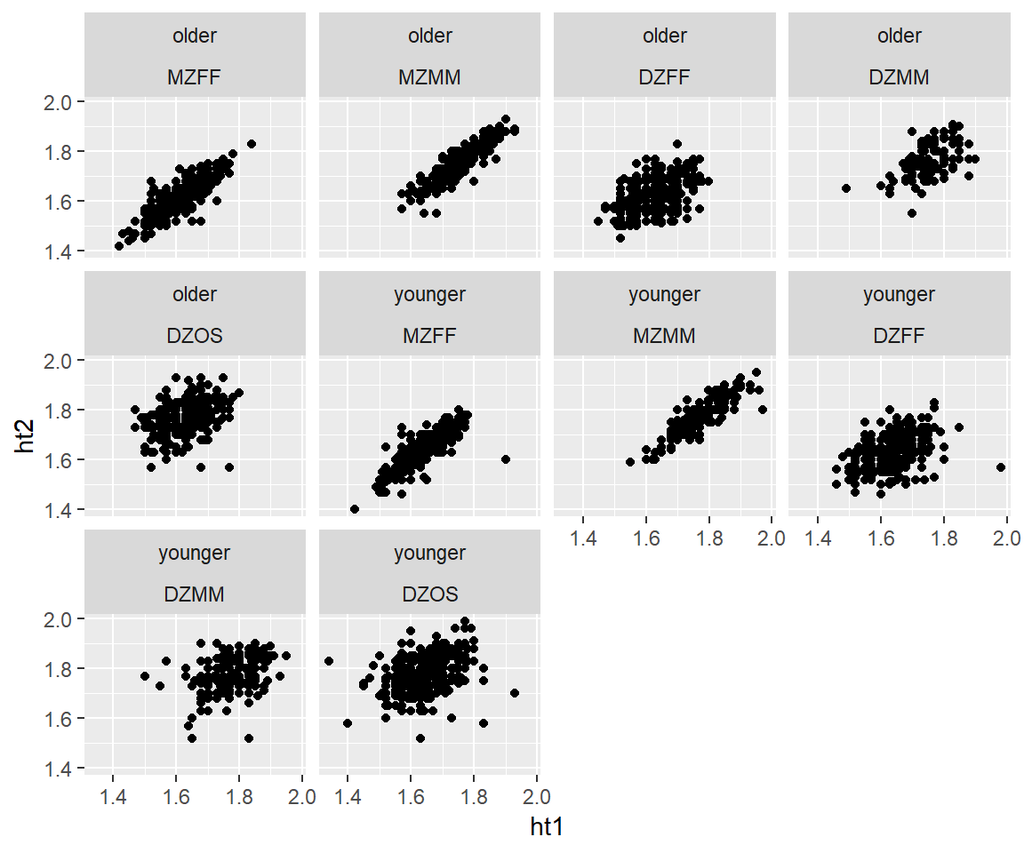

```r
library(ggplot2)
twinData %>%
  ggplot(mapping = aes(ht1, ht2)) +
  geom_point() +
  facet_wrap(cohort~zygosity)
```

4. Inspect the scatter plot(s) you created. What do you see?
- MZFF and MZMM: points are closely clustered around the diagonal line, which means the twins’ heights are strongly correlated.
- DZFF and DZMM: points are not as close to the diagonal as MZFF and MZMM. The correlation is kind of weak.
- DZOS, frateral twins with opposite sex: points are far from the diagonal.

To quantify your observation, we may test whether the correlation coefficient between the two variables, `ht1` and `ht2`, is greater than 50%. A statistical test to test whether the two variables, `ht1` and `ht2`, are correlated:

```r
twinData %>%
  with(cor.test(~ ht1 + ht2, alternative = "greater"))
```

```
##
##  Pearson's product-moment correlation
##
## data:  ht1 and ht2
## t = 47.757, df = 3665, p-value < 2.2e-16
## alternative hypothesis: true correlation is greater than 0
## 95 percent confidence interval:
##  0.6023115 1.0000000
## sample estimates:
##       cor
## 0.6193442
```

See that 95 percent confidence interval is [0.6023115, 1], the lower bound of which is “above” the prespecified 50%. If we make a conclusion that the true correlation coefficient is greater than 50%, then we are wrong for less than 5 percent of the time.

To repeat the test for each subgroup (defined by the values of `cohort` and `zygosity`), it is natural to use `group_by`. However, naively trying the following does not work:

```
twinData %>%
   group_by(cohort,zygosity) %>%
   summarze(cor.test(~ ht1 + ht2, data = .))
```

This is because the result of the function call `cor.test(~ ht1 + ht2, data = .)` is not a data frame, and is not tidy.

## Combine results from multiple analyses using `broom`

This is where we need an additional package, called `broom`, to help make the result of `cor.test()` tidy. We use the function `broom::tidy()`. Try the following.

```r
library(broom)
cor_result <- cor.test(~ ht1 + ht2, data = twinData)
tidy_cor_result <- tidy(cor_result)
```

See that `cor_result` is a list, not a data frame, but `tidy_cor_result` is a data frame.

```r
str(cor_result)
```

```
## List of 9
##  $ statistic  : Named num 47.8
##   ..- attr(*, "names")= chr "t"
##  $ parameter  : Named int 3665
##   ..- attr(*, "names")= chr "df"
##  $ p.value    : num 0
##  $ estimate   : Named num 0.619
##   ..- attr(*, "names")= chr "cor"
##  $ null.value : Named num 0
##   ..- attr(*, "names")= chr "correlation"
##  $ alternative: chr "two.sided"
##  $ method     : chr "Pearson's product-moment correlation"
##  $ data.name  : chr "ht1 and ht2"
##  $ conf.int   : num [1:2] 0.599 0.639
##   ..- attr(*, "conf.level")= num 0.95
##  - attr(*, "class")= chr "htest"
```

```r
str(tidy_cor_result)
```

```
## Classes 'tbl_df', 'tbl' and 'data.frame':    1 obs. of  8 variables:
##  $ estimate   : num 0.619
##  $ statistic  : num 47.8
##  $ p.value    : num 0
##  $ parameter  : int 3665
##  $ conf.low   : num 0.599
##  $ conf.high  : num 0.639
##  $ method     : chr "Pearson's product-moment correlation"
##  $ alternative: chr "two.sided"
```

We are almost there, but not quite yet. Notice that trying the following does not work. Why?

```
twinData %>%
  group_by(cohort,zygosity) %>%
  summarize(tidy( cor.test(~ ht1 + ht2, alternative = "greater" , data = . )))
```

The problem is that the arguments of the function `summarize()` must be of the form `var = value`. To get around this issue, we use `dplyr::do()`. `do()` means “Do anything”. This is a general purpose complement to the specialised manipulation functions `filter()`, `select()`, `mutate()`, `summarise()` and `arrange()`. You can use `do()` to perform arbitrary computation, returning either a data frame or arbitrary objects which will be stored in a list. This is particularly useful when working with models: you can fit models per group with `do()` and then flexibly extract components with either another `do()` or `summarise()`.

```r
twinData %>%
  group_by(cohort,zygosity) %>%
  do(tidy( cor.test(~ ht1 + ht2, alternative = "greater" , data = . )))
```

```
## # A tibble: 10 x 10
## # Groups:   cohort, zygosity [10]
##    cohort zygosity estimate statistic   p.value parameter conf.low
##    <chr>  <fct>       <dbl>     <dbl>     <dbl>     <int>    <dbl>
##  1 older  MZFF        0.859     42.6  1.66e-189       642    0.841
##  2 older  MZMM        0.907     36.4  1.09e-109       286    0.888
##  3 older  DZFF        0.456     10.1  1.06e- 21       387    0.388
##  4 older  DZMM        0.510      6.97 5.84e- 11       138    0.399
##  5 older  DZOS        0.381      8.00 7.65e- 15       378    0.306
##  6 young~ MZFF        0.877     42.7  8.60e-177       547    0.860
##  7 young~ MZMM        0.883     30.0  3.36e- 86       256    0.858
##  8 young~ DZFF        0.440      9.02 7.36e- 18       339    0.365
##  9 young~ DZMM        0.350      5.15 3.32e-  7       190    0.241
## 10 young~ DZOS        0.428     10.4  2.19e- 23       484    0.365
## # ... with 3 more variables: conf.high <dbl>, method <chr>,
## #   alternative <chr>
```

## Homework

5. Sort the result of above computation from the largest estimate of correlation coefficient to the smallest.

```r
twin_cor <-
  twinData %>%
  group_by(cohort,zygosity) %>%
  do(tidy( cor.test(~ ht1 + ht2, alternative = "greater" , data = . )))

twin_cor %>% arrange(desc(estimate))
```

```
## # A tibble: 10 x 10
## # Groups:   cohort, zygosity [10]
##    cohort zygosity estimate statistic   p.value parameter conf.low
##    <chr>  <fct>       <dbl>     <dbl>     <dbl>     <int>    <dbl>
##  1 older  MZMM        0.907     36.4  1.09e-109       286    0.888
##  2 young~ MZMM        0.883     30.0  3.36e- 86       256    0.858
##  3 young~ MZFF        0.877     42.7  8.60e-177       547    0.860
##  4 older  MZFF        0.859     42.6  1.66e-189       642    0.841
##  5 older  DZMM        0.510      6.97 5.84e- 11       138    0.399
##  6 older  DZFF        0.456     10.1  1.06e- 21       387    0.388
##  7 young~ DZFF        0.440      9.02 7.36e- 18       339    0.365
##  8 young~ DZOS        0.428     10.4  2.19e- 23       484    0.365
##  9 older  DZOS        0.381      8.00 7.65e- 15       378    0.306
## 10 young~ DZMM        0.350      5.15 3.32e-  7       190    0.241
## # ... with 3 more variables: conf.high <dbl>, method <chr>,
## #   alternative <chr>
```

6. Create a new variable to indicate whether the correlation coefficient between `ht1` and `ht2` in the particular subgroup is greater 0.5, with 95 percent confidence. Save the resulting data frame by the name `sig_twin_cor`.

```r
twin_cor <- twin_cor %>%
  mutate(sig50 = conf.low > 0.5)
sig_twin_cor <- twin_cor %>%
  filter(sig50 == TRUE)
sig_twin_cor
```

```
## # A tibble: 4 x 11
## # Groups:   cohort, zygosity [4]
##   cohort zygosity estimate statistic   p.value parameter conf.low conf.high
##   <chr>  <fct>       <dbl>     <dbl>     <dbl>     <int>    <dbl>     <dbl>
## 1 older  MZFF        0.859      42.6 1.66e-189       642    0.841         1
## 2 older  MZMM        0.907      36.4 1.09e-109       286    0.888         1
## 3 young~ MZFF        0.877      42.7 8.60e-177       547    0.860         1
## 4 young~ MZMM        0.883      30.0 3.36e- 86       256    0.858         1
## # ... with 3 more variables: method <chr>, alternative <chr>, sig50 <lgl>
```

7. List the only the combinations of `cohort` and `zygosity` where the twins’ heights are significantly *similar*. Here the similarity is defined by the test result, evaluated in #6.

```r
sig_twin_cor %>%
  select(cohort,zygosity)
```

```
## # A tibble: 4 x 2
## # Groups:   cohort, zygosity [4]
##   cohort  zygosity
##   <chr>   <fct>
## 1 older   MZFF
## 2 older   MZMM
## 3 younger MZFF
## 4 younger MZMM
```

We can see that no matter the twins are younger or olders, identical twins’ heights are significantly similar. This is a very intuitive result.

## Homework

8. Repeat exercise #3. This time, use the variables `cohort`, `zygosity` to facet, and use different colors to indicate the subgroups for which the heights are significantly similar. Comment on your finding.

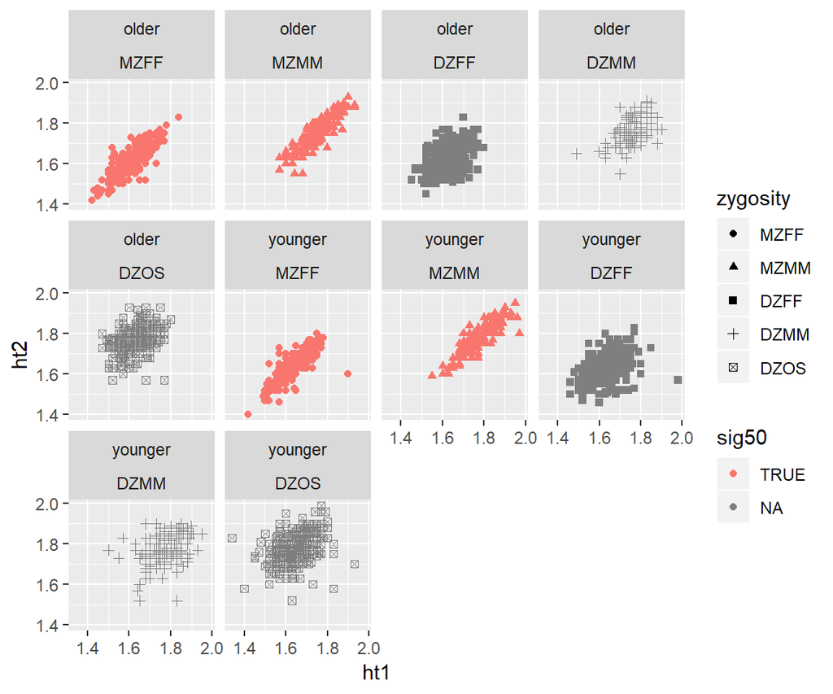

```r
left_join(twinData,sig_twin_cor, by = c("cohort","zygosity")) %>%
    ggplot(mapping = aes(ht1, ht2,color = sig50, shape = zygosity)) +
  geom_point() +
  facet_wrap(cohort~zygosity)
```

The following set of exercises is to answer the second question “Are the first-born taller than the second-born?” for each group given by the values of `cohort` and `zygosity`. We will use the paired t-test. You may want to go back to your Intro Stat textbook to learn about the paired t-test.

9. Recreate the following graphic. This involves transforming `twinData` into a narrow form using `gather()`. You might want to take a look at Lecture 5 slides for boxplots.

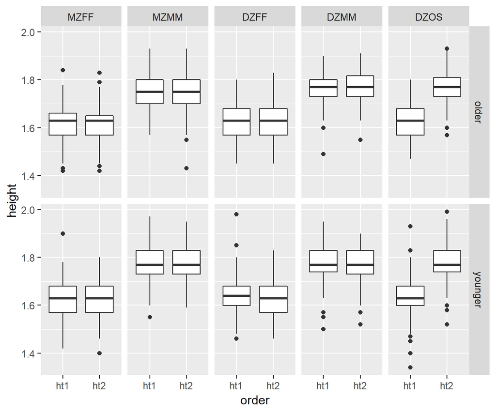

```r
twinData %>%
  select(cohort,zygosity,ht1,ht2) %>%
  gather(key = "order", value = "height", 3:4) %>%
  ggplot(aes(x = order, y = height)) +
  geom_boxplot() + facet_grid(cohort ~ zygosity)
```

```r
ggsave("twin_box.png")
```

10. Inspect the data graphic. Is there any need to adjust the hypothesis (posed in Question #2)?

Yes, because apparently for some cohort and zygosity combinations, the younger ones are taller on average.

We can use the paired t-test to test whether the first-born’s height is significantly different from the second-born for each subgroup at significance level 5%.

```r
twin_t <-
  twinData %>%
  select(cohort,zygosity,ht1,ht2) %>%
  group_by(cohort,zygosity) %>%
  do(tidy(t.test(.$ht1, .$ht2, paired = TRUE)))
twin_t
```

```
## # A tibble: 10 x 10
## # Groups:   cohort, zygosity [10]
##    cohort zygosity estimate statistic   p.value parameter conf.low
##    <chr>  <fct>       <dbl>     <dbl>     <dbl>     <dbl>    <dbl>
##  1 older  MZFF      1.27e-3     0.953 3.41e-  1       643 -1.35e-3
##  2 older  MZMM     -2.39e-4    -0.131 8.95e-  1       287 -3.82e-3
##  3 older  DZFF      3.14e-3     0.916 3.60e-  1       388 -3.60e-3
##  4 older  DZMM     -6.35e-3    -1.20  2.31e-  1       139 -1.68e-2
##  5 older  DZOS     -1.41e-1   -40.5   9.99e-140       379 -1.48e-1
##  6 young~ MZFF      1.80e-4     0.128 8.98e-  1       548 -2.58e-3
##  7 young~ MZMM      1.28e-3     0.635 5.26e-  1       257 -2.70e-3
##  8 young~ DZFF      7.61e-3     1.94  5.30e-  2       340 -9.86e-5
##  9 young~ DZMM      2.13e-3     0.376 7.07e-  1       191 -9.03e-3
## 10 young~ DZOS     -1.43e-1   -43.2   3.16e-168       485 -1.49e-1
## # ... with 3 more variables: conf.high <dbl>, method <chr>,
## #   alternative <chr>
```

11. Recreate the above graphic with different colors indicating the results of t-tests (based on p-value).

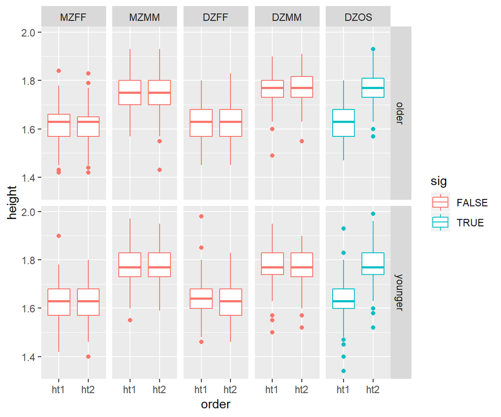

```r
twin_t_sig <-
  twin_t %>%
  mutate(sig = p.value < 0.05) %>%
  select(cohort, zygosity,sig)

twinData %>%
  select(cohort,zygosity,ht1,ht2) %>%
  gather(key = "order", value = "height", 3:4) %>%
  left_join(twin_t_sig, key = c("cohort","zygosity"))  %>%
  ggplot(aes(x = order, y = height, color = sig)) +
  geom_boxplot() +
  facet_grid(cohort ~ zygosity)
```